# Part II - Prosper Loan Data Explanation

## by Maryam OYEYIOLA

## Investigation Overview

> I am interested in finding out which features contribute to the amount of loan a borrower gets. I can already assume some features like `IsBorrowerHomeowner` and `IncomeRange` contribute to how much loan is disburesed, but I am not sure of the extent. While features like `Recommendations` and `LoanOriginationQuarter` may probably have no effect of the amount disbursed, I am interested in finding that out as well.

> A good amount of recommendations can go a long way in solidifying the decision of either giving an individual a loan or not

## Dataset Overview

> This data set contains 113,937 loans with 81 variables on each loan, including loan amount, borrower rate (or interest rate), current loan status, borrower income, and many others.

> This data [dictionary](https://docs.google.com/spreadsheets/d/1gDyi_L4UvIrLTEC6Wri5nbaMmkGmLQBk-Yx3z0XDEtI/edit#gid=0) explains the variables in the data set.

## Distribution of Loan Amount

> The loan amount with the highest frequency is between $1000-4000. While 35000 is the highest loan taken out by a borrower. The histogram is still right skewed, but has a multimodal distribution.

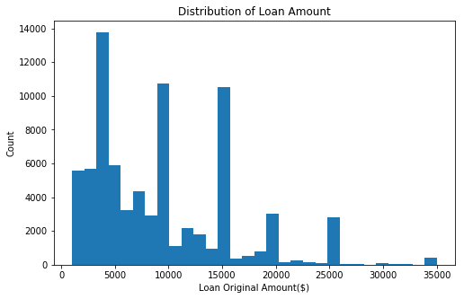

## Distribution of Monthly Loan Payment

> Outliers have been detected in the original data and the cleaned, the skeweness has been taken care of and the distribution now looks more spread across the x-axis. While we had a unimodal distribution initially, the new distribution turned out to be a bimodal distribution

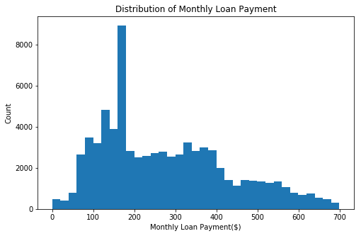

## Looking closely at the relationship between `MonthlyLoanPayment` and `LoanOriginalAmount`

> They are both right skewed and they share a 0.92% correlation

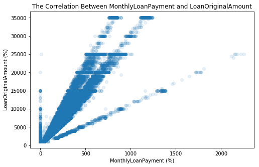

## The distribution of `BorrowerAPR` and `BorrowerRate`

> The `BorrowerAPR` is the annual cost of a loan to a borrower which includes the `BorrowerRate` and the other costs that have accured on the load that year. I suspect the distribution will be similar to the distribution `BorrowerRate`

> Both histohrams do share a certain level of similarity. The x-axis limit of `BorrowerAPR` is higher than `BorrowerRate`. This can be as a result of the addition chargeges that have been `BorroweRate` to get the `BorrowerAPR`. They might also share a positive correlation with each other.

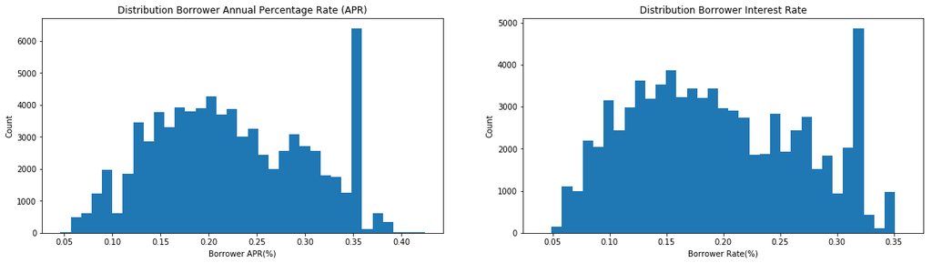

## Which quarter of the year do people take out loans most?

> Most of the loan action occur at Q1 (January-March) and Q4 (October-December). Q1 has New Year's and is right before Easter while Q4 has Thansgiving and Christmas holidays. Could this be the reason why more people take out loans during these months?

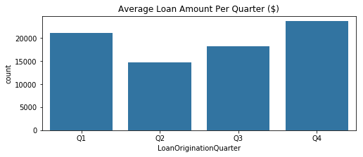

## Are there more high earners than there are low earners?

> About 90% of borrowers are employed and have taken out loans and earn at least 1-dolloar per year, while unemployed and self-employed people have not been able to take out any loans

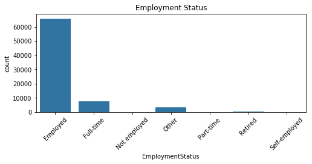

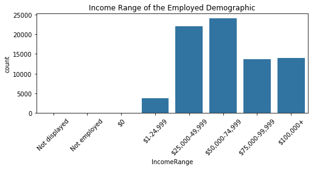

## What effect does the occupation of a borrower have on the loan amount they are granted?

> The professions that take out the highest amount of loan include **Pharmacy, Medicine(Doctor) and Jugde**. These professions do indeed hold a high prestige in the society. The average salary of anyone in any of the three professions is over ($)150,000

```
Text(0.5,1,' Average Loan Amount ($) by Occupation of Borrowers')
```

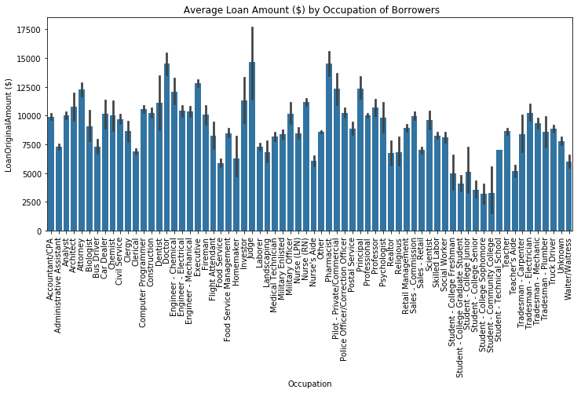

## `LoanOriginalAmount` by `ProsperRating (Alpha)` and `IsBorrowerHomeowner`

```
Text(0.5,1,'LoanOriginalAmount by ProsperRating (Alpha) and IsBorrowerHomeowner')
```

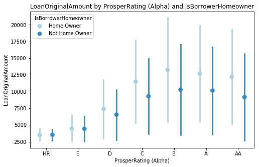

## `LoanOriginalAmount` by `ProsperScore` and `IncomeRange`

```
Text(0.5,1,'LoanOriginalAmount by LoanOriginalAmount and IncomeRange')
```

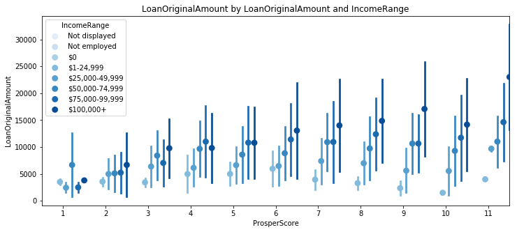